# 5 Parameter estimation

In Chapter 4 we introduced the bootstrap filter, an algorithm which returns a particle approximation to $P(X_t | y_{1:T}, \theta)$. Critically, this posterior distribution depends on parameter(s) $\theta$. This chapter is dedicated to performing inference on $\theta$ itself.

We start by showing how the bootstrap filter can be used to estimate the log-likelihood of $\theta$. We then use this log-likelihood (and a corresponding prior distribution) to develop a posterior distribution for $\theta$. Two approaches for this are demonstrated:

- A grid-based approach, useful for simple 1-dimensional cases
- Particle marginal Metropolis Hastings (PMMH), useful for more complicated cases, and in Chapter 6 where we use the output to find the marginal posterior of $X_t$.

If your goal is to perform inference on $\theta$, then you are done! In the frequentist setting, you have access to a likelihood upon which you can base your inferences (e.g. Section 5.5.2). In the Bayesian setting you have the desired posterior distribution.

If your goal is to perform inference on $X_t$ after accounting for uncertainty in $\theta$, then you can use the posterior distribution to marginalise out $\theta$. This is demonstrated in Chapter 6.

## 5.1 Likelihood estimation

The log-likelihood of $\theta$ is defined as:

$$\ell(\theta|y_{1:T}) = \log P(y_{1:T}|\theta) = \sum_{t=1}^T \log P(y_t| y_{1:t-1}, \theta)
\tag{5.1}$$

The second equality in Equation 5.1 is called the *predictive decomposition of the likelihood*, which decomposes the likelihood into one-step-ahead predictions.

We draw attention to the fact that our hidden-states $X_t$ do not feature in Equation 5.1, whereas our model (the state-space and observation distributions) depend heavily on these variables. This is where the predictive decomposition is useful, as the bootstrap filter produces a convenient way of estimating $P(y_t| y_{1:t-1}, \theta)$, at no extra cost.

First we write the predictive distribution as an expectation of the observation distribution $P(y_t|X_{1:t}, y_{1:t-1}, \theta)$:
$$\begin{align}
P(y_t | y_{1:t-1}, \theta) &= \int P(y_t | X_{1:t}, y_{1:t-1}, \theta) P(X_{1:t} | y_{1:t-1}, \theta) \ dX_{1:t}\\
&= E_{X_{1:t}|y_{1:t-1}, \theta}\left[P(y_t|X_{1:t}, y_{1:t-1}, \theta)\right]
\end{align}
\tag{5.2}$$

This expectation is taken with respect to $X_{1:t}$, conditional on $y_{1:t-1}$ and $\theta$. The bootstrap filter generates samples of these $X_{1:t}$ in the projection step (?eq-smc-bootstrapprojection), denoted $\tilde{x}_{1:t}^{(i)}$. Thus, we can approximate the expectation (and thus the predictive likelihood) using:
$$P(y_t | y_{1:t-1}, \theta) \approx \frac{1}{N} \sum_{i=1}^N P\left(y_t | \tilde{x}_{1:t}^{(i)}, y_{1:t-1}, \theta\right)
\tag{5.3}$$

Finally, we highlight that $P\left(y_t | \tilde{x}_{1:t}^{(i)}, y_{1:t-1}, \theta\right)$ is precisely the weight of the $i^{th}$ particle at time-step $t$, and thus:

$$P(y_t |y_{1:t-1}, \theta) \approx \frac{1}{N} \sum_{i=1}^N w_t^{(i)} = \bar{w}_t
\tag{5.4}$$

Combining equations Equation 5.1 and Equation 5.4 we find:

$$\hat{\ell}(\theta|y_{1:T}) = \sum_{t=1}^T \log \bar{w}_t
\tag{5.5}$$

These weights are calculated within the bootstrap filter, so approximating the log-likelihood simply requires us to calculate and store the average weights at each step. Compared to the core bootstrap filter, this computation is trivial.

### 5.1.1 Example

We continue with the example from ?sec-smc-bootstrapexample. For simplicity, we package up the bootstrap into a single function that returns a matrix of hidden-state samples $X$ and a same-sized matrix of weights $W$ (click on the arrow to expand code).

```julia
using Distributions, Plots, Measures
include("../src/loadData.jl")
nzdata = loadData("NZCOVID")

# Specify the serial interval and initial distribution for Rt
ω = pdf.(Gamma(2.36, 2.74), 1:100)
ω = ω/sum(ω)
pR0 = Uniform(0, 10)

# Create the function to run the boostrap-filter
function runBootstrapFilter(σ, nzdata; N=10000, L=50)

    # Initialise output matrices
    T = length(nzdata.Ct)
    X = zeros(N, T)
    W = zeros(N, T)

    # Sample from initial distribution
    X[:,1] = rand.(pR0, N)

    # Run the filter
    for tt = 2:T

        # Project according to the state-space model
        X[:,tt] = exp.(rand.(Normal.(log.(X[:,tt-1]), σ)))

        # Weight according to the observation model
        Λ = sum(nzdata.Ct[tt-1:-1:1] .* ω[1:tt-1])
        W[:,tt] = pdf.(Poisson.(X[:,tt] .* Λ), nzdata.Ct[tt])

        # Resample
        inds = wsample(1:N, W[:,tt], N; replace=true)
        X[:, max(tt - L, 1):tt] = X[inds, max(tt - L, 1):tt]

    end

    return(X, W)

end
```

```
runBootstrapFilter (generic function with 1 method)
```

The log-likelihood of $\sigma$ is estimated by summing the logarithm of the columnwise means of $W$, ignoring the first column as we do not calculate weights for this time-step (the renewal model requires at least one day of past data to calculate $\Lambda_t^c$):

```julia
σ = 0.1
(X, W) = runBootstrapFilter(σ, nzdata)
loglik = sum(log.(mean(W, dims=1)[2:end]))
println("Estimated log-likelihood = $loglik")
```

```
Estimated log-likelihood = -220.70446122703086
```

### 5.1.2 Variance of log-likelihood estimates

We use $\hat{\ell}$ to emphasise that Equation 5.5 is an estimate of the likelihood $\ell$. Practically speaking, the variance of this estimator depends on:

- How well the model fits: if the projection-step places particles in more plausible regions of the support of the observation-distribution the variance of the log-weights decreases.
- The dimensionality of the observations: higher dimenionsal observation-distributions spread probability mass over a wider area, increasing the variance of log-weights.
- The length of data: the likelihood estimator is a sum of stochastic terms, so the variance scales approximately linearly with $T$.
- The number of particles used: more particles increases the effective sample size at each time-step, decreasing the variance of the log-likelihood estimator.

The bootstrap filter outlined above used $N = 10000$ particles for $T = 100$ days. The standard deviation of the log-likelihood estimator can itself be (crudely) estimated by:

```julia
logliks = zeros(100)
Threads.@threads for ii = 1:100 # The Threads macro is used to leverage multiple cores
    (X, W) = runBootstrapFilter(σ, nzdata)
    logliks[ii] = sum(log.(mean(W, dims=1)[2:end]))
end
println("Sample variance of log-lik estimates = $(std(logliks))")
```

```
Sample variance of log-lik estimates = 0.44892089421787496
```

## 5.2 Grid-based posterior distribution

In the simplest case, where $\theta$ is 1-D and discrete (with a sufficiently small range), we can simply estimate $\ell(\theta|y_{1:T})$ on all values of $\theta$. If $\theta$ is 1-D and continuous, then we can estimate it on a grid of values. Given prior distribution $P(\theta)$, Bayes’ formula can be used to estimate $P(\theta|y_{1:T})$.

*In the grid-based case, if we assume a discrete prior distribution over the grid, then our posterior distribution is exact. If we approximate our prior distribution with a discretised prior distribution, then our posterior distribution is also an approximation - although the difference is purely philosophical.*

### 5.2.1 Example (continued)

We can run the bootstrap filter on a range of values of $\sigma$. We also store the values of all particles so we can later visualise $P(R_t|y_{1:T}, \sigma)$ for each value of $\sigma$:

```julia
N = 100000 # We use additional particles so the algorithm works well even when using poor choices of σ
σvalues = 0.06:0.01:0.4
logliks = zeros(length(σvalues))
X = zeros(N, length(nzdata.Ct), length(σvalues))
for (ii, σ) in enumerate(σvalues)
    (Xi, W) = runBootstrapFilter(σ, nzdata; N=N)
    logliks[ii] = sum(log.(mean(W, dims=1)[2:end]))
    X[:,:,ii] = Xi
end
```

If we assume a discrete uniform prior distribution for `σvalues`, we can calculate the posterior distribution as follows:

```julia
σposterior  = exp.(logliks .- maximum(logliks))
σposterior = σposterior/sum(σposterior)
```

Plotting the log-likelihood of $\sigma$ alongside the filtering distribution for $R_t$ highlights that $\sigma = 0.1$ is *probably* too low, and results in substantially different estimates of $R_t$ relative to estimates using more likely values of $\sigma$.

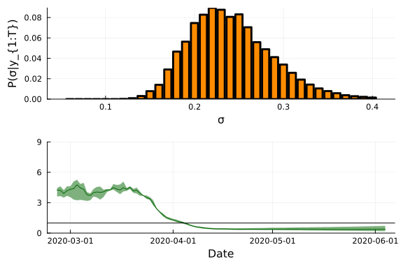

```julia
# # Make animated plot of filtering values
# σvalues_str = string.(σvalues)
# (σvalues_str[3], σvalues_str[8], σvalues_str[13], σvalues_str[18]) = ("0.10", "0.20", "0.30", "0.40")

anim = @animate for (ii, σ) in enumerate(σvalues)

    animPlot = plot(layout=grid(2,1, heights=[0.5, 0.5]), size=(600, 400), left_margin=3mm, bottom_margin=3mm)

    # Plot log-lik
    barcolors = repeat([:darkorange], length(σvalues))
    barcolors[ii] = :darkgreen
    bar!(animPlot[1], σvalues, σposterior, label=false, fill=barcolors, linewidth=3)
    # vline!(animPlot[1], [σ], label=false)
    # ylims!(animPlot[1], (-220, -209))
    xlabel!(animPlot[1], "σ")
    ylabel!(animPlot[1],"P(σ|y_{1:T})")

    # Plot Rt estimates
    T = size(X)[2]
    m = [mean(X[:,tt,ii]) for tt in 1:T]
    l = [quantile(X[:,tt,ii], 0.025) for tt in 1:T]
    u = [quantile(X[:,tt,ii], 0.975) for tt in 1:T]
    plot!(animPlot[2], nzdata.date, m, ribbon=(m-l, u-m), label=false, color=:darkgreen)
    hline!(animPlot[2], [1], label=false, color=:black)
    ylims!(animPlot[2], (0, 9))
    xlabel!(animPlot[2], "Date")
    # ylabel!(animPlot[2], "Filtering Rt | σ = $(σvalues_str[ii])")

end

gif(anim, fps=5, verbose=false, show_msg=false)
```

## 5.3 Particle marginal Metropolis Hastings

### 5.3.1 Algorithm

### 5.3.2 Example (continued)

## 5.4 Concluding remarks

The estimates of $\theta$ as presented here assume that the model is correctly specified, however this almost certainly is not the case.

In the context of the example, we highlight the presence of unmodelled observation noise as a particular concern here: any noise in the data beyond that implied by the Poisson observation distribution is attributed to changes in $R_t$ (that is, is incorporated in estimates of $\sigma$). There are almost certainly additional sources of noise, so we are likely over-estimating $\sigma$. This is dicscussed further in Chapter 9.

## 5.5 Other methods

### 5.5.2 Iterated filtering and POMP

Theoretically, this algorithm can estimate parameter vectors that would otherwise be intractable in a Bayesian setting. Their examples are restricted to Markovian models, limiting their applicability to renewal models, although including the relevant state-history in $X_t$ is a potential way around this problem (at the cost of a substantially increased model dimensionality).

The authors use different terminology in places. POMP refers to Hidden Markov Models (HMMs), which are hidden-state models with Markovian hidden-state transitions. “Plug-and-play” refers to simulation-based inference methods (i.e. those that only require a simulator of the model, rather than direct evaluations of a likelihood function).

#### 5.5.2.2 The “three criteria”

The authors emphasise three criteria for comparing inference methods on HMMs:

1. The “plug-and-play” property
2. Full-information or feature-based
3. Frequentist or Bayesian

The “plug-and-play” property refers to simulation-based inference: a method is called “plug-and-play” if it only requires a simulator of the hidden-state model, rather than explicit likelihood evaluations.

Full-information methods are those based on the likelihood function for the full data, whereas feature-based methods consider summary statistics or an alternative to the likelihood. Generally, full-information models are preferred, although feature-based methods can be useful if they improve computational efficiency.

The primary difference between their methodology and ours, is their focus on frequentist-inference.

The methods introduced on this website are simulation-based (so satisfy the “plug-and-play” criteria), generally leverage full-information, and are Bayesian. The methods presented in `POMP` are similar in the first two regards, although are generally (but not always) frequentist in nature.

There are obvious cases where we do not leverage full-information, e.g. when working with temporally aggregated data. However, in these cases the approximation occurs in the *model*, rather than the *method*, meaning our methods still leverage full-information in this context.

Ionides, E. L., C. Bretó, and A. A. King. 2006. “Inference for Nonlinear Dynamical Systems.” *Proceedings of the National Academy of Sciences* 103 (49): 18438–43. https://doi.org/10.1073/pnas.0603181103.

Ionides, Edward L., Anindya Bhadra, Yves Atchadé, and Aaron King. 2011. “Iterated Filtering.” *The Annals of Statistics* 39 (3). https://doi.org/10.1214/11-AOS886.

Ionides, Edward L., Dao Nguyen, Yves Atchadé, Stilian Stoev, and Aaron A. King. 2015. “Inference for Dynamic and Latent Variable Models via Iterated, Perturbed Bayes Maps.” *Proceedings of the National Academy of Sciences* 112 (3): 719–24. https://doi.org/10.1073/pnas.1410597112.

Kantas, Nikolas, Arnaud Doucet, Sumeetpal S. Singh, Jan Maciejowski, and Nicolas Chopin. 2015. “On Particle Methods for Parameter Estimation in State-Space Models.” *Statistical Science* 30 (3): 328–51. https://doi.org/10.1214/14-STS511.

King, Aaron A., Dao Nguyen, and Edward L. Ionides. 2016. “Statistical Inference for Partially Observed Markov Processes via the *R* Package **Pomp**.” *Journal of Statistical Software* 69 (12). https://doi.org/10.18637/jss.v069.i12.